# BIRINTZI_MARKELLA_02153

### **ΕΡΓΑΣΙΑ ΕΞΗΑΜΗΝΟΥ ΒΑΘΕΙΑΣ ΜΑΘΗΣΗΣ** ΧΕΙΜΕΡΙΝΟ ΕΞΑΜΗΝΟ 2026

> ΜΠΙΡΙΝΤΖΗ ΜΑΡΚΕΛΛΑ

## **ΤΡΟΠΟΣ ΕΠΙΛΥΣΗΣ**

# Παρακάτω αναφέρονται τα βήματα για την επίλυση του προβλήματος:

> > 1)IMPORTING NECESSARY LIBRARIES

> > 2)IMPORTING NEWS DATA & VISUALIZATION

> > 3)DATA PREPPING(10TOP CATEGORIES)

> > 4)DATA PRE-PROCESSING

> > > 4.1)CLEANING THE CORPUS

> > > 4.2)STOPWORDS REMOVAL

> > > 4.3)STEMMING

> > > 4.4)LABEL ENCODING

> > 5)TOKENS VISUALIZATION-WORDCLOUD

> > 6)TOKENIZATION

> > 7)PADDING OF SEQUENCES

> > 8)GLOVE(EMBEDDING MATRIX)

> > 9)LSTM

> > 10)TRAINING & OPTIMIZATION

> > 11)RESULTS

> > > 11.1)LEARNING CURVES

> > > 11.2)CONFUSION MATRIX

> > > 11.3)CLASSIFICATION REPORT(precision,recall,f1-score)

## **ΣΥΝΤΟΜΗ ΒΙΒΛΙΟΓΡΑΦΙΚΗ ΑΝΑΣΚΟΠΗΣΗ**

> Herranz Andres(2021,11 Μαίου).*NLP 📝 GloVe, BERT, TF-IDF, LSTM... 📝 Explained*.KAGGLE.Ανάκτηση 26/11/25 από https://www.kaggle.com/code/andreshg/nlp-glove-bert-tf-idf-lstm-explained

> [2].(2025,12 Αυγούστου).*Glove Word Embedding in NLP)*.Ανάκτηση 26/11/25 από https://www.geeksforgeeks.org/nlp/glove-word-embedding-in-nlp/

> [3].(2025,23 Δεκεμβρίου).*What is LSTM - Long Short Term Memory?*.Ανάκτηση 26/11/2025 από https://www.geeksforgeeks.org/deep-learning/deep-learning-introduction-to-long-short-term-memory/

**Ανάκτηση NEWS CATEGORY DATASET από Kaggle**

```python
import kagglehub

# Download latest version
path = kagglehub.dataset_download("rmisra/news-category-dataset")

print("Path to dataset files:", path)
```

```
Path to dataset files: C:\Users\mpiri\.cache\kagglehub\datasets\rmisra\news-category-dataset\versions\3
```

Εδώ για τις απαιτήσεις της εργασίας ήταν απαραίτητο να κατεβάσουμε τις βιβλιοθήκες **kagglehub,tensorflow** οι οποιές έχουν εγκατασταθεί ήδη στο περιβάλλον μας.

```python
#!pip install kagglehub
#!pip install tensorflow
```

# 1)IMPORTING NECESSARY LIBRARIES

```python
import os
import csv
import tensorflow as tf
import numpy as np
import pandas as pd
from tensorflow.keras.preprocessing.text import Tokenizer
from tensorflow.keras.preprocessing.sequence import pad_sequences
import matplotlib.pyplot as plt
import re
import string
import nltk
from nltk.corpus import stopwords
from nltk.stem import SnowballStemmer
from sklearn.preprocessing import LabelEncoder
from wordcloud import WordCloud
from nltk import word_tokenize
from sklearn.model_selection import train_test_split
from tensorflow.keras.models import Sequential
from tensorflow.keras.layers import Embedding, LSTM, Dense, Bidirectional, GlobalMaxPool1D, BatchNormalization, Dropout
from tensorflow.keras.callbacks import ModelCheckpoint, ReduceLROnPlateau
from sklearn.metrics import confusion_matrix
from sklearn import metrics
from sklearn.utils import class_weight
from sklearn.metrics import classification_report, accuracy_score
```

# 2)IMPORTING NEWS DATA & VISUALIZATION

```python
#Εντοπίζουμε το αρχείο στον φάκελο που είναι αποθηκευμένο
file_name = os.listdir(path)[0]
full_path = os.path.join(path, file_name)

# Διάβασμα του dataset και απεικόνιση ενός ενδεικτικού τμήματος
df = pd.read_json(full_path, lines=True)
df.head()
```

|  | link | headline | category | short_description | authors | date |
| --- | --- | --- | --- | --- | --- | --- |
| 0 | https://www.huffpost.com/entry/covid-boosters-... | Over 4 Million Americans Roll Up Sleeves For O... | U.S. NEWS | Health experts said it is too early to predict... | Carla K. Johnson, AP | 2022-09-23 |
| 1 | https://www.huffpost.com/entry/american-airlin... | American Airlines Flyer Charged, Banned For Li... | U.S. NEWS | He was subdued by passengers and crew when he ... | Mary Papenfuss | 2022-09-23 |
| 2 | https://www.huffpost.com/entry/funniest-tweets... | 23 Of The Funniest Tweets About Cats And Dogs ... | COMEDY | "Until you have a dog you don't understand wha... | Elyse Wanshel | 2022-09-23 |
| 3 | https://www.huffpost.com/entry/funniest-parent... | The Funniest Tweets From Parents This Week (Se... | PARENTING | "Accidentally put grown-up toothpaste on my to... | Caroline Bologna | 2022-09-23 |
| 4 | https://www.huffpost.com/entry/amy-cooper-lose... | Woman Who Called Cops On Black Bird-Watcher Lo... | U.S. NEWS | Amy Cooper accused investment firm Franklin Te... | Nina Golgowski | 2022-09-22 |

Στο παρακάτω κελί θα αφαιρέσουμε προληπτικά την περίπτωση να υπάρχουν γραμμές με **NA(Not available) τιμές** , οι οποίες δεν έχουυν κάποια χρησιμότητα. Έπειτα θα κρατήσουμε μόνο τις στήλες που θα χρειαστούμε όπου είναι η **τιμή στόχος (category)** στην οποία ανήκει η είδηση και τα **χαρακτηριστικά εισόδου** που είναι η **σύντομη περιγραφή(short_description)** και ο **τίτλος (headline)**

```python
df=df.dropna(how="any",axis=0) #διώχνω γραμμές που εχουν ΝΑ τιμές
df=df[['headline', 'short_description', 'category']] #dataframe μόνο με τις στήλες που χρειάζομαι
df.head()
```

|  | headline | short_description | category |
| --- | --- | --- | --- |
| 0 | Over 4 Million Americans Roll Up Sleeves For O... | Health experts said it is too early to predict... | U.S. NEWS |
| 1 | American Airlines Flyer Charged, Banned For Li... | He was subdued by passengers and crew when he ... | U.S. NEWS |
| 2 | 23 Of The Funniest Tweets About Cats And Dogs ... | "Until you have a dog you don't understand wha... | COMEDY |
| 3 | The Funniest Tweets From Parents This Week (Se... | "Accidentally put grown-up toothpaste on my to... | PARENTING |
| 4 | Woman Who Called Cops On Black Bird-Watcher Lo... | Amy Cooper accused investment firm Franklin Te... | U.S. NEWS |

Παρακάτω απεικονίζεται ένα ραβδόγραμμα στο οποίο φαίνονται και οι **42 κατηγορίες** νέων και τον αριθμό των άρθρων σε κάθε κατηγορία. Είναι φανερή η μεγάλη απόκλιση του πλήθος ειδήσεων που έχουν κάποιες κατηγορίες μεταξύ τους κάτι που πρέπει να λάβουμε υπόψη στην συνέχεια.

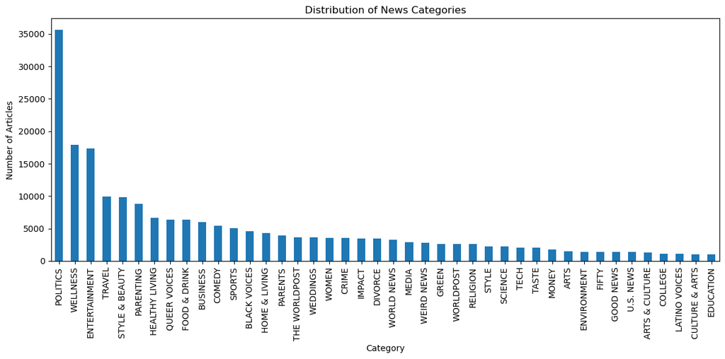

```python
category_counts=df['category'].value_counts() #καταμέτρηση των τιμών καθε κατηγορίας

#κατασκευή διαγράμματος
plt.figure(figsize=(12, 6))
category_counts.plot(kind='bar')
plt.title('Distribution of News Categories')
plt.xlabel('Category')
plt.ylabel('Number of Articles')
plt.xticks(rotation=90)
plt.tight_layout()
plt.show()
```

# 3)DATA PREPPING(10TOP CATEGORIES)

Αν παίρναμε και τις 42 κατηγορίες θα αυξανόταν σε μεγάλο βαθμό η πολυπλοκότητα του προβλήματος και το μοντέλο θα χρειαζόταν περισσότερο χρόνο και πόρους για να μπορέσει να κάνει σωστή πρόβλεψη. Άρα το επόμενο λογικό βήμα είναι να κρατήσουμε τις **10 επικρατέστερες κατηγορίες** ώστε να έχουμε επαρκή δεδομένα αλλά και αξιοπιστία στα αποτελέσματα μας. Παρακάτω φλιρτάρουμε την **στήλη category** ώστε να κρατήσουμε μόνο τα άρθρα που ανήκουν σε μία απο αυτές τις κατηγορίες.

```python
categories_top=['POLITICS','WELLNESS','ENTERTAINMENT','TRAVEL','STYLE & BEAUTY','PARENTING','HEALTHY LIVING','QUEER VOICES','FOOD & DRINK','BUSINESS']
df_new=df[df['category'].isin(categories_top)].copy() #στην category ελέγχει αν κάθε γραμμή είναι top_categorie και κρατάει μονο αυτές
df_new.head()
```

|  | headline | short_description | category |
| --- | --- | --- | --- |
| 3 | The Funniest Tweets From Parents This Week (Se... | "Accidentally put grown-up toothpaste on my to... | PARENTING |
| 20 | Golden Globes Returning To NBC In January Afte... | For the past 18 months, Hollywood has effectiv... | ENTERTAINMENT |
| 21 | Biden Says U.S. Forces Would Defend Taiwan If ... | President issues vow as tensions with China rise. | POLITICS |
| 24 | ‘Beautiful And Sad At The Same Time’: Ukrainia... | An annual celebration took on a different feel... | POLITICS |
| 28 | James Cameron Says He 'Clashed' With Studio Be... | The "Avatar" director said aspects of his 2009... | ENTERTAINMENT |

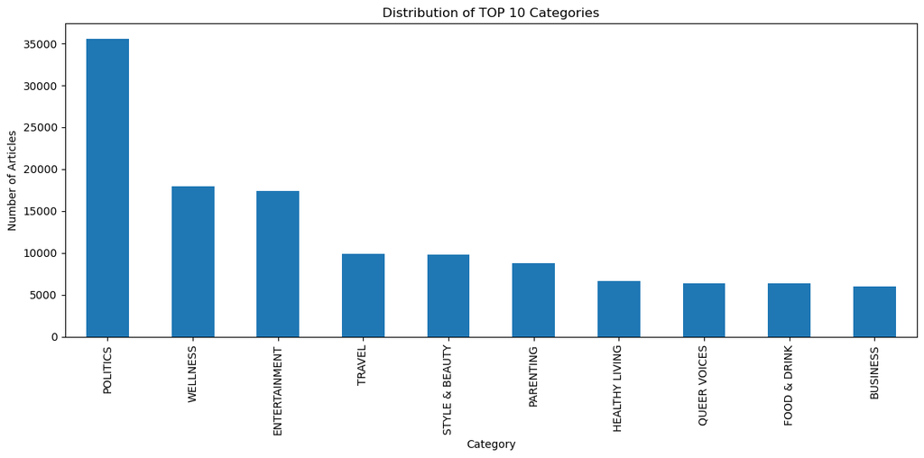

```python
category_counts=df_new['category'].value_counts() #καταμέτρηση των τιμών κάθε κατηγορίας

#κατασκευή διαγράμματος
plt.figure(figsize=(12, 6))
category_counts.plot(kind='bar')
plt.title('Distribution of TOP 10 Categories')
plt.xlabel('Category')
plt.ylabel('Number of Articles')
plt.xticks(rotation=90)
plt.tight_layout()
plt.show()
```

# 4)DATA PRE-PROCESSING

> Σε αυτή την ενότητα στόχος ειναι ο καθαρισμός των δεδομένων που στην περίπτωση μας είναι κείμενα, από περιττά σημεία στίξης,συχνές λέξεις/stopwords (the,is,a,on,e.t.c),urls,emails.Ύστερα θα χρησιμοποιήσουμε την τεχνική **stemming** η οποία έχει ως σκοπό να αφαιρέσει την κατάληξη από λέξεις με κοινή ρίζα (π.χ. politician,politics,political) ώστε να μπορέσει να τις αντιλαμβάνετε το νευρωνικό δίκτυο ως λέξεις με ίδια σημασία.

# 4.1 CLEANING THE CORPUS

> Με την παρακάτω συνάρτηση **clean_text** μετατρέπουμε όλα τα γράμματα σε μικρά,αφαιρούμε σημεία στίξης,αλλαγές γραμμής,συνδιασμόι λέξεων με γράμματα,urls,emails

```python
def clean_text(text):
    text=str(text).lower()   #όλα τα γράμματα μικρά
    text=re.sub('[%s]'%re.escape(string.punctuation),'',text)  #διαγραφή σημείων στοίξης
    text=re.sub('\n','',text)  #αφαιρεί αλλαγές γραμμής
    text=re.sub('\w*\d\w*','',text) #αφαιρεί συνδιασμούς αριθμών-λέξεων π.χ.12iphone
    text=re.sub(r'http\S+|www\S+|https\S+', '', text)#αφαιρε΄΄ί  urls
    text=re.sub(r'\S+@\S+', '', text)  #αφαιρεί emails
    return text
```

# 4.2)STOPWORDS REMOVAL

> H παρακάτω συνάρτηση έχει ως σκοπό την αφαίρεση λέξεων τύπου(the,is,on,mine,e.t.c) οι οποίες συνήθως έχουν συνδετικό ρόλο στην πρόταση και δεν έχουν κάποια αξία ως πληροφορία για το μοντέλο μας.

```python
#nltk.download('stopwords')
stop_words=stopwords.words('english')

def remove_stopwords(text):
     #έλεγχος κάθε λέξης αν ανήκει στην λίστα με τα stop_words αν όχι την κρατάμε.
    text=' '.join(word for word in text.split(' ') if word not in stop_words)
    return text
```

# 4.3)STEMMING

> Με την παρακάτω συνάρτηση όλες οι λέξεις του κειμένου διαχωρίζονται και με την **τεχνική stemming** όλες οι λέξεις με κοινή ρίζα αλλά διαφορετική κατάληξη εκλαμβάνονται ότι έχουν ίδια σημασία.

```python
stemmer=nltk.SnowballStemmer('english')
def stemm_text(text):
    text=' '.join(stemmer.stem(word) for word in text.split(' '))
    return text
```

Η παρακάτω συνάρτηση περιέχει όλες τις παραπάνω συναρτήσεις και έπειτα δημιουργούμε μια νέα στήλη **combined_text** που περιέχει τον **τίτλο** και την **σύντομη περιγραφή** για ευκολότερη επεξεργασία.Και η στήλη **text_clean** ειναι η συνάρτηση που ορίσαμε παραπάνω για να την εφαρμόσουμε στην στήλη **combined_text** και να προκύψει το καθαρό αποτέλεσμα με τις λέξεις στην στήλη text_clean.

```python
def preprocess_data(text):
    text=clean_text(text)
    text=remove_stopwords(text)
    text=stemm_text(text)

    return text

df_new['combined_text']=df_new['headline']+" "+df_new['short_description']
df_new['text_clean']=df_new['combined_text'].apply(preprocess_data)
df_new.head()
```

|  | headline | short_description | category | combined_text | text_clean |
| --- | --- | --- | --- | --- | --- |
| 3 | The Funniest Tweets From Parents This Week (Se... | "Accidentally put grown-up toothpaste on my to... | PARENTING | The Funniest Tweets From Parents This Week (Se... | funniest tweet parent week sept accident put ... |
| 20 | Golden Globes Returning To NBC In January Afte... | For the past 18 months, Hollywood has effectiv... | ENTERTAINMENT | Golden Globes Returning To NBC In January Afte... | golden globe return nbc januari year offair pa... |
| 21 | Biden Says U.S. Forces Would Defend Taiwan If ... | President issues vow as tensions with China rise. | POLITICS | Biden Says U.S. Forces Would Defend Taiwan If ... | biden say us forc would defend taiwan china in... |
| 24 | ‘Beautiful And Sad At The Same Time’: Ukrainia... | An annual celebration took on a different feel... | POLITICS | ‘Beautiful And Sad At The Same Time’: Ukrainia... | beauti sad time ukrainian cultur festiv take d... |
| 28 | James Cameron Says He 'Clashed' With Studio Be... | The "Avatar" director said aspects of his 2009... | ENTERTAINMENT | James Cameron Says He 'Clashed' With Studio Be... | jame cameron say clash studio avatar releas av... |

# 4.4)LABEL ENCODING

> Παρακάτω χρησιμοποιούμε **LabelEncoder** ώστε να μπορέσει το νευρωνικό δίκτυο να διαχωρίσει τις 10 κατηγορίες καθώς δεν αναγνωρίζει τις λέξεις οπότε είναι απαραίτητη η αντιστοίχηση της κάθε κατηγορίες σε αριθμούς.Συγκεκριμένα απο 0-9.

```python
le=LabelEncoder()
le.fit(df_new['category'])
df_new['category_encoded']=le.transform(df_new['category']) #μετατροπή των κατηγοριών σε αριθμούς
df_new.head()
```

|  | headline | short_description | category | combined_text | text_clean | category_encoded |
| --- | --- | --- | --- | --- | --- | --- |
| 3 | The Funniest Tweets From Parents This Week (Se... | "Accidentally put grown-up toothpaste on my to... | PARENTING | The Funniest Tweets From Parents This Week (Se... | funniest tweet parent week sept accident put ... | 4 |
| 20 | Golden Globes Returning To NBC In January Afte... | For the past 18 months, Hollywood has effectiv... | ENTERTAINMENT | Golden Globes Returning To NBC In January Afte... | golden globe return nbc januari year offair pa... | 1 |
| 21 | Biden Says U.S. Forces Would Defend Taiwan If ... | President issues vow as tensions with China rise. | POLITICS | Biden Says U.S. Forces Would Defend Taiwan If ... | biden say us forc would defend taiwan china in... | 5 |
| 24 | ‘Beautiful And Sad At The Same Time’: Ukrainia... | An annual celebration took on a different feel... | POLITICS | ‘Beautiful And Sad At The Same Time’: Ukrainia... | beauti sad time ukrainian cultur festiv take d... | 5 |
| 28 | James Cameron Says He 'Clashed' With Studio Be... | The "Avatar" director said aspects of his 2009... | ENTERTAINMENT | James Cameron Says He 'Clashed' With Studio Be... | jame cameron say clash studio avatar releas av... | 1 |

# 5)TOKEN VISUALIZATION-WORDCLOUD

> Mια ενδιαφέρουσα τεχνική για να οπτικοποιήσουμε τις πιο συχνές λέξεις της κάθε κατηγορίας είναι μέσω του **WORDCLOUD** για να εγκρίνουμε αν ο καθαρισμός που κάναμε παραπάνω έχει αποτέλεσμα.Όσο πιο μεγάλη η λέξη και έντονη τόσο πιο συχνά εμφανίζεται στην συγκεκριμένη κατηγορία.

```python
#!pip install wordcloud
```

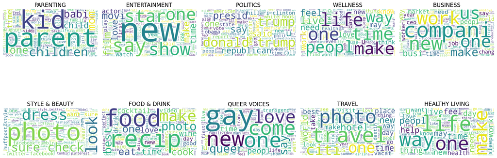

```python
categories=df_new['category'].unique() #παίρνει τις κατηγορίες μια φορά την κάθε μια

plt.figure(figsize=(20,10))

for i,cat in enumerate(categories,1):  #loop για να βάζουμε την κάθε κατηγοριά σε καθε επανάληψη στην σωστή θέση(αρχίζει απο 1) στο γράφημα.
    text=' '.join(df_new[df_new['category']==cat]['text_clean'])

    wordcloud = WordCloud(width=800, height=400, background_color='white').generate(text)

    plt.subplot(2,5,i)#2 σειρες,5 στηλες,το i=θέση στο γράφημα
    plt.imshow(wordcloud, interpolation='bilinear')
    plt.axis('off')
    plt.title(cat, fontsize=16)
plt.tight_layout()
plt.show()
```

```python
texts=df_new['text_clean']
category=df_new['category_encoded']
```

# 6)TOKENIZATION

> Επειδή το νευρωνικό δίκτυο όπως είπαμε παραπάνω δεν αναγνωρίζει λέξεις αλλά αριθμούς,σε αυτό το στάδιο θα αντιστοιχήσουμε την κάθε μοναδική λέξη με έναν μοναδικό ακέραιο αριθμό που θα την αντιπροσωπεύει.

Αρχικά δημιουργούμε ενα 'λεξικό' **word_index** που περιέχει τις μοναδικές λέξεις από το texts, οι οποίες έχουν αντιστοιχηθεί με αριθμό/ID σύμφωνα με την συχνότητα τους.Όσο μικρότερος αριθμός τόσο πιο συχνή η λέξη.

```python
tokenizer=Tokenizer()
tokenizer.fit_on_texts(texts)    # σάρωση της texts και καταγραφή την συχνότητα των λέξεων

vocab_length=len(tokenizer.word_index)+1
vocab_length     #πόσες μοναδικές λέξεις εχει το λεξικό
```

```
61882
```

```python
#nltk.download('punkt_tab')
```

# 7)PADDING OF SEQUENCES

> Με την **συνάρτηση embed** θα αντικαταστήσουμε τα tokens με τους αριθμούς/ID παραπάνω και θέλουμε να βρούμε το μεγαλύτερο κείμενο ,ώστε να οριστεί το σταθερό μέγεθος που θα πρέπει να έχουν όλες οι ειδήσεις. Ως τελικό αποτέλεσμα θα πάρουμε έναν **πίνακα train_padded_sequneces** που οι αρiθμοί είναι οι λέξεις και κάθε γραμμή είναι ένα κείμενο, που έχει το μέγεθος του μεγαλύτερου κειμένου. Στα κείμενα που είναι μικρότερα χρησιμοποιούμε **padding** δηλαδή γεμίζουμε με 0 στο τέλος ώστε να έχει κάθε γραμμή ίδιο μέγεθος στον πίνακα μας.

```python
def embed(corpus):
    return tokenizer.texts_to_sequences(corpus) # μετατροπή κάθε λέξης με το ID της από το word_index.

#'σπάμε' την κάθε προταση σε tokens ,μετράμε το μέγεθος και αποθηκεύουμε αυτή με τα περισσότερα tokens.
longest_train=max(texts,key=lambda sentence:len(word_tokenize(sentence)))

##Ο αριθμός που θα προκύψει ορίζει το μέγεθος του πίνακα.
length_long_sentence=len(word_tokenize(longest_train))

train_padded_sequences=pad_sequences(


    embed(texts),
    length_long_sentence,
    padding='post' #padding με μηδενικά στο τέλος όπου χρειάζεται
)
train_padded_sequences
```

```
array([[ 3528,   359,    61, ...,     0,     0,     0],
       [ 1045,  1134,   508, ...,     0,     0,     0],
       [  591,    11,     5, ...,     0,     0,     0],
       ...,
       [  447,  1054,   179, ...,     0,     0,     0],
       [ 4256, 19499,  1947, ...,     0,     0,     0],
       [  180,  4193,  2582, ...,     0,     0,     0]], dtype=int32)
```

# 8)GLOVE(EMBEDDING MATRIX)

> Το **GloVe (Global Vectors for Word Representation)** είναι ένας αλγόριθμος μάθησης χωρίς επίβλεψη, σχεδιασμένος για τη δημιουργία πυκνών διανυσματικών αναπαραστάσεων, γνωστών και ως ενσωματώσεων. Ο κύριος στόχος του είναι η καταγραφή των σημασιολογικών σχέσεων μεταξύ λέξεων, αναλύοντας τα μοτίβα συνύπαρξής τους σε ένα μεγάλο σώμα κειμένων.[2]

Το Glove έχει προκαθορισμένα πυκνά διανύσματα για περίπου κάθε **6 δισεκατομμύρια λέξεις αγγλικής λογοτεχνίας**, μαζί με πολλούς άλλους χαρακτήρες όπως κόμματα, αγκύλες και ερωτηματικά. Μπορεί να ληφθεί και να χρησιμοποιηθεί άμεσα σε πολλές εφαρμογές επεξεργασίας φυσικής γλώσσας (NLP). Οι χρήστες μπορούν να επιλέξουν ένα προ-εκπαιδευμένο GloVe που ενσωματώνεται σε μια διάσταση όπως διανύσματα 50d, 100d, 200d ή 300d που ταιριάζει καλύτερα στις ανάγκες τους όσον αφορά τους υπολογιστικούς πόρους και την εξειδίκευση της εργασίας Το **embeddings_dictionary** ειναι ουσιαστικά ο χώρος που θα αποθηκεύσουμε αυτό το αρχείο του GLOVE με την κάθε λέξη και το διάνυσμα της με διάσταση 100d.[2]

```python
embeddings_dictionary=dict()

embedding_dim=100 #θα επιλέξουμε τα 100d δηλαδή 100 χαρακτηριστικά για κάθε λέξη.
path_to_glove = 'glove.6B.100d.txt' # το αρχείο GLOVE

with open(path_to_glove, encoding='utf-8') as fp:
    for line in fp: #διάβασμα του αρχείου
        records = line.split() #χωρίζει την κάθε γραμμή σε στοιχεία
        word = records[0] #η λε΄ξη πριν τα 100 χαρακτηριστικά της
        vector_dimensions = np.asarray(records[1:], dtype='float32') #δημιουργία πίνακα με τα διανύσματα των λέξεων σε μορφή δεκαδικών
        embeddings_dictionary[word] = vector_dimensions #έχουμε αποθηκεύσει κάθε λέξη και το διάνυσμα της.
```

Ωστόσο ο παραπάνω matrix περιέχει όλες τις λέξεις του GLOVE κάτι που δεν χρειαζόμαστε καθώς μας ενδιαφέρουν μόνο οι λέξεις που βρίσκονται στο λεξικό που φτιάξαμε προηγουμένως(word_index).Άρα θα φτιάξουμε έναν **πίνακα(embedding_matrix)** όπου αρχικά θα έχει μηδενικά και στην συνέχεια θα παίρνουμε με την σειρά κάθε λέξη με τον αντίστοιχο ID της από το λεξικό μας(word_index), ύστερα ψάχνουμε την λέξη στο embeddings_dictionary που περιέχει όλες τις λέξεις του GLOVE και αν την βρούμε αποθηκεύουμε στην σειρά που υποδηλώνει το ID της το διάνυσμα 100d.

```python
embedding_matrix=np.zeros((vocab_length,embedding_dim))
for word,index in tokenizer.word_index.items():  #για καθε  ζευγάρι λέξη-ID του λεξικού word_index
    embedding_vector=embeddings_dictionary.get(word) #παίρνω το διάνυσμα 100d της κάθε λέξης
    if embedding_vector is not None: #αν βρεθεί η λέξη στο GLOVE
        embedding_matrix[index]=embedding_vector #αποθήκευση του διανύσματος στην αντιστοιχή σειρα σύμφωνα με το ID.
```

# 9)LSTM

> Η **Μακροχρόνια Βραχυπρόθεσμη Μνήμη (LSTM)** είναι μια βελτιωμένη έκδοση του **Επαναλαμβανόμενου Νευρωνικού Δικτύου (RNN)** που σχεδιάστηκε από τους Hochreiter και Schmidhuber. Τα LSTM μπορούν να καταγράψουν μακροπρόθεσμες εξαρτήσεις σε διαδοχικά δεδομένα, καθιστώντας τα ιδανικά για εργασίες όπως η μετάφραση γλώσσας, η αναγνώριση ομιλίας και η πρόβλεψη χρονοσειρών. Σε αντίθεση με τα παραδοσιακά RNN που χρησιμοποιούν μία μόνο κρυφή κατάσταση που διαβιβάζεται στο χρόνο, τα LSTM εισάγουν ένα κελί μνήμης που διατηρεί πληροφορίες για εκτεταμένες περιόδους, αντιμετωπίζοντας την πρόκληση της εκμάθησης μακροπρόθεσμων εξαρτήσεων.[3]

TRAIN/TEST SPLIT

```python
X_train,X_test,y_train,y_test=train_test_split(
    train_padded_sequences, #δεδομένα εισόδου
    df_new['category_encoded'].values, #δεδομένα εξόδου
    test_size=0.25,
    random_state=101 #επιβεβαίωση τυχαιοτητάς σε κάθε επανάληψη


)
```

Η παρακάτω συνάρτηση **glove_lstm** περιέχει τα επίπεδα που χρειάζεται το LSTM.

Συγκεκριμένα ειναι:

1)Το **Embedding layer**:Στέλνει στο LSTM επίπεδο το διάνυσμα 100d που υπάρχει στο embedding_matrix για κάθε λέξη/ID που υπάρχει σε κάθε είδηση.(από το train_padded_sequences array)

2)**Bidirectional LSTM**:Διαβάζει την πρόταση και από τις δύο κατευθύνσεις και αποθηκέυει τις πληροφορίες για κάθε λέξη.

3)**GlobalMaxPool1D &BatchNormalization**:Κρατάμε την πιο σημαντική πληροφορία που μας δίνει το LSTM layer και την σταθεροποιούμε.

4)**Dropout & Dense**:Αντιμετώπιση overfitting και κατανόηση σχέσεων μεταξύ των χαρακτηριστικών κρατώντας τις σημαντικές τιμές.

5)**Dense10,activation='softmax'**:Μας δινει πιθανότητες να ανήκει η είδηση σε μια απο τις 10 κατηγορίες.Κρατάμε την μεγαλύτερη πιθανότητα.

```python
def glove_lstm():

    model=Sequential()
    #FIRST LAYER
    model.add(Embedding(
        input_dim=embedding_matrix.shape[0],#αριθμός των γραμμών του embedding_matrix (61.881)
        output_dim=embedding_matrix.shape[1],#αριθμός των στηλών (100d)
        weights=[embedding_matrix],# τροφοδοτεί έτοιμο τον πινακα embedding_matrix
        ))
   #SECOND LAYER
    model.add(Bidirectional(LSTM(
        length_long_sentence,#πλήθος νευρώνων ανάλογα με την μεγαλύτερη πρόταση
        return_sequences=True,
        recurrent_dropout=0.2 #το 20% των συνδέσεων δεν λαμβάνονται υπόψη
        )))
    model.add(GlobalMaxPool1D())
    model.add(BatchNormalization())
    model.add(Dropout(0.5))
    model.add(Dense(length_long_sentence,activation="relu"))
    model.add(Dropout(0.5))
    model.add(Dense(length_long_sentence,activation="relu"))

    model.add(Dense(10,activation='softmax')) #
    model.compile(loss='sparse_categorical_crossentropy', optimizer='adam', metrics=['accuracy'])

    return model
model=glove_lstm()
model.build(input_shape=(None, length_long_sentence))
model.summary()
```

```
Model: "sequential"
```

```
┏━━━━━━━━━━━━━━━━━━━━━━━━━━━━━━━━━━━━━━┳━━━━━━━━━━━━━━━━━━━━━━━━━━━━━┳━━━━━━━━━━━━━━━━━┓
┃ Layer (type)                         ┃ Output Shape                ┃         Param # ┃
┡━━━━━━━━━━━━━━━━━━━━━━━━━━━━━━━━━━━━━━╇━━━━━━━━━━━━━━━━━━━━━━━━━━━━━╇━━━━━━━━━━━━━━━━━┩
│ embedding (Embedding)                │ (None, 142, 100)            │       6,188,200 │
├──────────────────────────────────────┼─────────────────────────────┼─────────────────┤
│ bidirectional (Bidirectional)        │ (None, 142, 284)            │         276,048 │
├──────────────────────────────────────┼─────────────────────────────┼─────────────────┤
│ global_max_pooling1d                 │ (None, 284)                 │               0 │
│ (GlobalMaxPooling1D)                 │                             │                 │
├──────────────────────────────────────┼─────────────────────────────┼─────────────────┤
│ batch_normalization                  │ (None, 284)                 │           1,136 │
│ (BatchNormalization)                 │                             │                 │
├──────────────────────────────────────┼─────────────────────────────┼─────────────────┤
│ dropout (Dropout)                    │ (None, 284)                 │               0 │
├──────────────────────────────────────┼─────────────────────────────┼─────────────────┤
│ dense (Dense)                        │ (None, 142)                 │          40,470 │
├──────────────────────────────────────┼─────────────────────────────┼─────────────────┤
│ dropout_1 (Dropout)                  │ (None, 142)                 │               0 │
├──────────────────────────────────────┼─────────────────────────────┼─────────────────┤
│ dense_1 (Dense)                      │ (None, 142)                 │          20,306 │
├──────────────────────────────────────┼─────────────────────────────┼─────────────────┤
│ dense_2 (Dense)                      │ (None, 10)                  │           1,430 │
└──────────────────────────────────────┴─────────────────────────────┴─────────────────┘
```

```
 Total params: 6,527,590 (24.90 MB)
```

```
 Trainable params: 6,527,022 (24.90 MB)
```

```
 Non-trainable params: 568 (2.22 KB)
```